# Bike Sharing: Data Visualization Project

## Investigation Overview

In this project, I wanted to explore how the bike sharing system is utilized over time and by which type of users. I focused on the trips' duration and the number of trips with respect to different time periods (year, month, day, day of week, hour), and user type (subscriber/casual customer).

## Dataset Overview

The original data contained nearly 2.4 million records for years 2017-2018 (record = anonymized bike trip), and 14 features. I kept all records, but only a subset of the features. After data wrangling, which included data type conversions and engineering of new features from the existing ones, the final dataset contains 9 features:

- start and end station names
- user type
- year, month, day, day of week, and hour when the bike trip started
- duration of a trip

```python
# Import all packages and set plots to be embedded inline
import numpy as np
import pandas as pd
import matplotlib.pyplot as plt
import seaborn as sb

%matplotlib inline

# Suppress warnings from final output
import warnings
warnings.simplefilter('ignore')
```

```python
# Load in the dataset into a pandas dataframe
bikes = pd.read_pickle('data/bike_shares_master.pkl')
bikes.head()
```

|  | start_station_name | end_station_name | user_type | year | month | day | weekday | hour | duration_min |
| --- | --- | --- | --- | --- | --- | --- | --- | --- | --- |
| 0 | Laguna St at Hayes St | San Francisco Public Library (Grove St at Hyde... | Customer | 2017 | December | 31 | Sunday | 16 | 1335.166667 |
| 1 | Yerba Buena Center for the Arts (Howard St at ... | Dolores St at 15th St | Customer | 2017 | December | 31 | Sunday | 15 | 1313.333333 |
| 2 | Downtown Berkeley BART | Downtown Berkeley BART | Customer | 2017 | December | 31 | Sunday | 22 | 762.800000 |
| 3 | 8th St at Ringold St | Powell St BART Station (Market St at 5th St) | Customer | 2017 | December | 31 | Sunday | 17 | 1036.200000 |
| 4 | Bancroft Way at Telegraph Ave | Fulton St at Bancroft Way | Subscriber | 2017 | December | 31 | Sunday | 14 | 726.716667 |

## Distribution of the number of bike trips over months in 2017 and 2018

The highest number of bike trips happen from May to October 2018; winter and spring months are weaker. Since the Ford GoBike service started operating in summer 2017, the data is incomplete, and the number of trips peaks in September and October.

The number of trips increases from June to October 2017, then slightly decreases in November and December 2017. However, it begins to rise from January 2018 again.

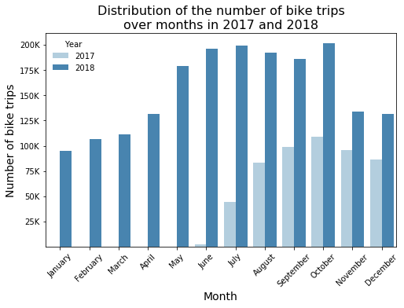

```python
# Create clustered bar chart to show year vs. month number of rides
plt.figure(figsize = (8, 5))
sb.countplot(data = bikes, x = 'month', hue = 'year', palette = 'Blues')
plt.title('Distribution of the number of bike trips\nover months in 2017 and 2018', fontsize = 16)
plt.legend(title = 'Year', loc = 'upper left', frameon = False)
plt.xlabel('Month', fontsize = 14)
plt.ylabel('Number of bike trips', fontsize = 14)
plt.xticks(rotation = 45)
plt.yticks(np.arange(25000, 225000, 25000), ['25K', '50K', '75K', '100K', '125K', '150K', '175K', '200K']);
```

## Distribution of the number of bike trips over days of week (2017 and 2018)

In general, the work days (Mondays to Fridays) tend to have more trips when compared to weekends (Saturdays and Sundays). This is true for both years 2017 and 2018.

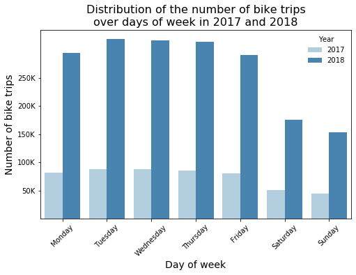

```python
# Create clustered bar chart to show year vs. day number of rides
plt.figure(figsize = (8, 5))
sb.countplot(data = bikes, x = 'weekday', hue = 'year', palette = 'Blues')
plt.title('Distribution of the number of bike trips\nover days of week in 2017 and 2018', fontsize = 16)
plt.legend(title = 'Year', loc = 'upper right', frameon = False)
plt.xlabel('Day of week', fontsize = 14)
plt.ylabel('Number of bike trips', fontsize = 14)
plt.xticks(rotation = 45)
plt.yticks(np.arange(50000, 300000, 50000), ['50K', '100K', '150K', '200K', '250K', '300K']);
```

## Distribution of the number of trips during day time by day of week (2017 and 2018)

```python
# Define function to create a pivot table to visualize in a heatmap
def create_counts_pivot(data, rows, columns):
    ride_counts = data.groupby([rows, columns]).size()
    ride_counts = ride_counts.reset_index(name = 'count')
    ride_counts = ride_counts.pivot(index = rows, columns = columns, values = 'count')
    return ride_counts
```

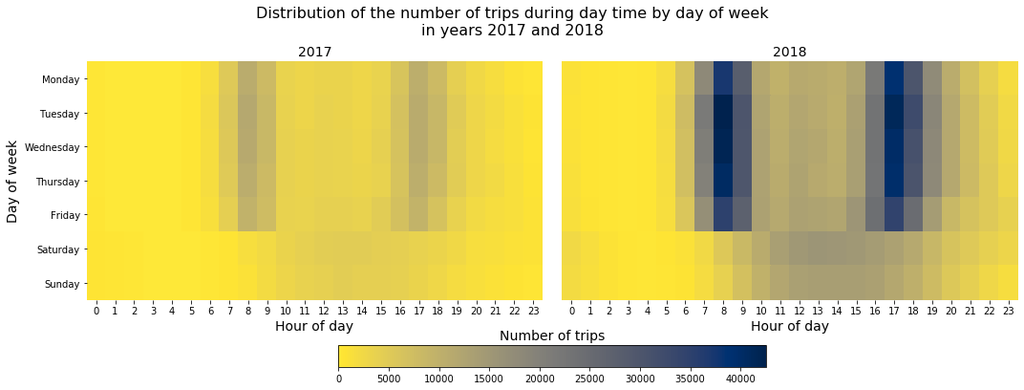

```python
# Create proper data structures
ride_counts_17 = create_counts_pivot(bikes[bikes['year'] == 2017], 'weekday', 'hour')
ride_counts_18 = create_counts_pivot(bikes[bikes['year'] == 2018], 'weekday', 'hour')

# Create heatmaps
fig, axs = plt.subplots(1, 2, figsize = (15, 6))
fig.suptitle('Distribution of the number of trips during day time by day of week\nin years 2017 and 2018', fontsize = 16)
min_count = 0
max_count = ride_counts_18.max().max()

# Left
ax1 = sb.heatmap(ride_counts_17, ax = axs[0], cmap = 'cividis_r', vmin = min_count, vmax = max_count, cbar = False)
ax1.set_xlabel('Hour of day', fontsize = 14)
ax1.set_ylabel('Day of week', fontsize = 14)
ax1.set_title('2017', fontsize = 14)

# Right
ax2 = sb.heatmap(ride_counts_18, ax = axs[1], cmap = 'cividis_r', vmin = min_count, vmax = max_count, cbar = False)
ax2.set_xlabel('Hour of day', fontsize = 14)
ax2.set_ylabel('')
ax2.set_title('2018', fontsize = 14)
ax2.get_yaxis().set_ticks([])

# Adjust the spacing
fig.tight_layout(w_pad = 2, rect=[0, 0, 1, 0.91])

# Add colorbar with title
mappable = ax2.get_children()[0]
cbar = fig.colorbar(mappable, ax = [ax1, ax2], orientation = 'horizontal', fraction=.070)
cbar.ax.set_title('Number of trips', rotation = 0, fontsize = 14);
```

## Distribution of the number of trips during day time by day of week: Subscribers vs. customers

There is a difference between subscribers' and customers' trips distributions - while the subscribers' trips happen most often on week days, the casual customers' trips happen most often on weekends. However, customers use the bike sharing system also during the peak hours on work days.

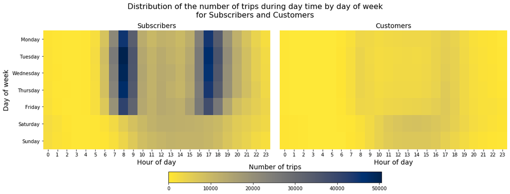

```python
# Create proper data structures
ride_counts_sub = create_counts_pivot(bikes[bikes['user_type'] == 'Subscriber'], 'weekday', 'hour')
ride_counts_cus = create_counts_pivot(bikes[bikes['user_type'] == 'Customer'], 'weekday', 'hour')

# Create heatmaps
fig, axs = plt.subplots(1, 2, figsize = (15, 6))
fig.suptitle('Distribution of the number of trips during day time by day of week\nfor Subscribers and Customers', fontsize = 16)
min_count = 0
max_count = ride_counts_sub.max().max()

# Left
ax1 = sb.heatmap(ride_counts_sub, ax = axs[0], cmap = 'cividis_r', vmin = min_count, vmax = max_count, cbar = False)
ax1.set_xlabel('Hour of day', fontsize = 14)
ax1.set_ylabel('Day of week', fontsize = 14)
ax1.set_title('Subscribers', fontsize = 14)

# Right
ax2 = sb.heatmap(ride_counts_cus, ax = axs[1], cmap = 'cividis_r', vmin = min_count, vmax = max_count, cbar = False)
ax2.set_xlabel('Hour of day', fontsize = 14)
ax2.set_ylabel('')
ax2.set_title('Customers', fontsize = 14)
ax2.get_yaxis().set_ticks([])

# Adjust the spacing
fig.tight_layout(w_pad = 2, rect=[0, 0, 1, 0.91])

# Add colorbar with title
mappable = ax2.get_children()[0]
cbar = fig.colorbar(mappable, ax = [ax1, ax2], orientation = 'horizontal', fraction=.070)
cbar.ax.set_title('Number of trips', rotation = 0, fontsize = 14);
```

## Distribution of the number of trips during day time by customer (2017 and 2018)

If the counts were not split by the day of week, it looks like the subscribers' trips follow the bimodal distribution typical for work days, and the customers' trips follow the unimodal weekend distribution.

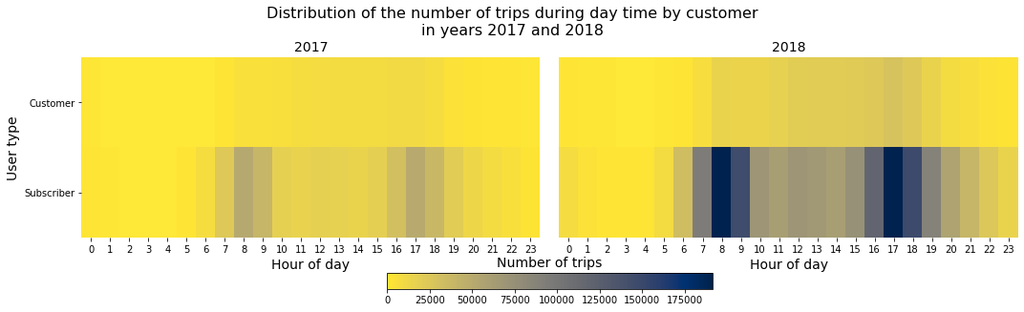

```python
# Create proper data structures
ride_counts_17 = create_counts_pivot(bikes[bikes['year'] == 2017], 'user_type', 'hour')
ride_counts_18 = create_counts_pivot(bikes[bikes['year'] == 2018], 'user_type', 'hour')


# heatmap_subplots(ride_counts_17, ride_counts_18, min_count, max_count, 'Hour of day', 'User type', '2017', '2018');

# Create heatmaps
fig, axs = plt.subplots(1, 2, figsize = (15, 5))
fig.suptitle('Distribution of the number of trips during day time by customer\nin years 2017 and 2018', fontsize = 16)
min_count = 0
max_count = ride_counts_18.max().max()

# Left
ax1 = sb.heatmap(ride_counts_17, ax = axs[0], cmap = 'cividis_r', vmin = min_count, vmax = max_count, cbar = False)
ax1.set_xlabel('Hour of day', fontsize = 14)
ax1.set_ylabel('User type', fontsize = 14)
ax1.set_title('2017', fontsize = 14)

# Right
ax2 = sb.heatmap(ride_counts_18, ax = axs[1], cmap = 'cividis_r', vmin = min_count, vmax = max_count, cbar = False)
ax2.set_xlabel('Hour of day', fontsize = 14)
ax2.set_ylabel('')
ax2.set_title('2018', fontsize = 14)
ax2.get_yaxis().set_ticks([])

# Rotate x-axis labels
for ax in axs:
    plt.setp(ax.get_yticklabels(), rotation = 0)

# Adjust the spacing
fig.tight_layout(w_pad = 2, rect=[0, 0.03, 1, 0.91])

# Add colorbar with title
mappable = ax2.get_children()[0]
cbar = fig.colorbar(mappable, ax = [ax1, ax2], orientation = 'horizontal', fraction=.070)
cbar.ax.set_title('Number of trips', rotation = 0, fontsize = 14);
```

## Trip duration distribution during year and week: Subscribers vs. customers

Subscribers' trips tend to take approximately the same time irrespective of the day and month, and are shorter than customers' trips. In other words, longer trips including the weekend ones are made by casual customers in all months.

```python
# Define function for log transformation
def log_trans(x, inverse = False):
    if not inverse:
        return np.log10(x)
    else:
        return np.power(10, x)
```

```python
# Convert duration for plotting purposes
bikes['duration_log'] = log_trans(bikes['duration_min'])
```

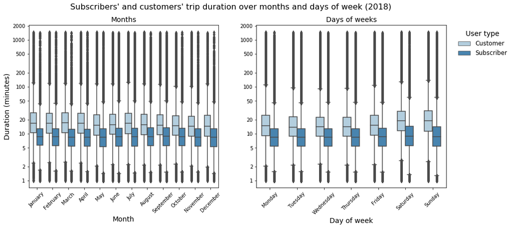

```python
# Create box plots to show relationship ride duration - user type - month/week day - 2018
fig, axs = plt.subplots(1, 2, figsize = (15, 6))
fig.suptitle('Subscribers\' and customers\' trip duration over months and days of week (2018)', fontsize = 16)

tick_locs = [1, 2, 5, 10, 20, 50, 100, 200, 500, 1000, 2000]

# Left - month
ax1 = sb.boxplot(data = bikes[bikes['year'] == 2018], x = 'month', y = 'duration_log',
                 ax = axs[0], hue = 'user_type', palette = 'Blues')
ax1.set_title('Months', fontsize = 14)
ax1.set_xlabel('Month', fontsize = 14)
ax1.set_ylabel('Duration (minutes)', fontsize = 14)
ax1.set_yticks(log_trans(tick_locs), tick_locs)
ax1.get_legend().remove()

# Right - week day
ax2 = sb.boxplot(data = bikes[bikes['year'] == 2018], x = 'weekday', y = 'duration_log',
                 ax = axs[1], hue = 'user_type', palette = 'Blues', width = 0.6)
ax2.set_title('Days of weeks', fontsize = 14)
ax2.set_xlabel('Day of week', fontsize = 14)
ax2.set_ylabel('')
ax2.set_yticks(log_trans(tick_locs), tick_locs)
ax2.set_ylim(ax1.get_ylim())

# Rotate x-axis labels
for ax in axs:
    plt.setp(ax.get_xticklabels(), rotation = 45)

# Set y-axis tick labels
plt.setp(axs, yticks = log_trans(tick_locs), yticklabels = tick_locs)

# Set legend
plt.legend(title = 'User type', bbox_to_anchor=(1.35, 1.0), title_fontsize = 14, fontsize = 12, frameon = False);
```

#### Resources:

- [Hiding axis text in matplotlib plots](https://stackoverflow.com/questions/2176424/hiding-axis-text-in-matplotlib-plots)
- [Figure Title](https://matplotlib.org/3.1.1/gallery/subplots_axes_and_figures/figure_title.html)
- [Multi Image](https://matplotlib.org/gallery/images_contours_and_fields/multi_image.html#sphx-glr-gallery-images-contours-and-fields-multi-image-py)
- [matplotlib: colorbars and its text labels](https://stackoverflow.com/questions/15908371/matplotlib-colorbars-and-its-text-labels)
- [Top label for matplotlib colorbars](https://stackoverflow.com/questions/33737427/top-label-for-matplotlib-colorbars)
- [Matplotlib tight_layout() doesn't take into account figure suptitle](https://stackoverflow.com/questions/8248467/matplotlib-tight-layout-doesnt-take-into-account-figure-suptitle)
- [Rotate tick labels in subplot (Pyplot, Matplotlib, gridspec)](https://stackoverflow.com/questions/31186019/rotate-tick-labels-in-subplot-pyplot-matplotlib-gridspec/52461208)
- [Python xticks in subplots](https://stackoverflow.com/questions/19626530/python-xticks-in-subplots)